# Differential abundance at genus and ASV levels

Calculated differential abundance at genus, species, and ASV levels.

Calculate number of taxa that are differentially abundant for each level

[output not shown]

Genus level bar plots showing the log2 fold change for taxa that are differentially abundant at an adjusted pvalue < 0.05.

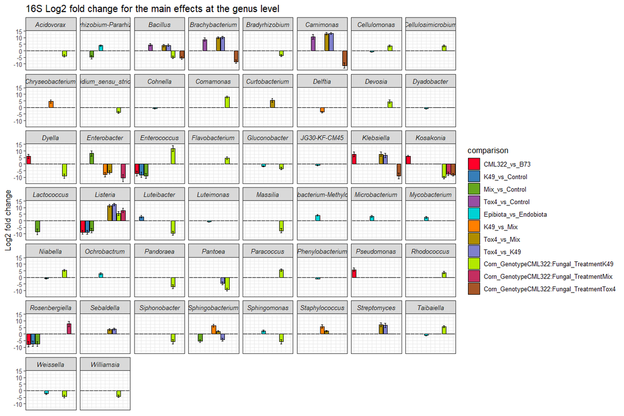

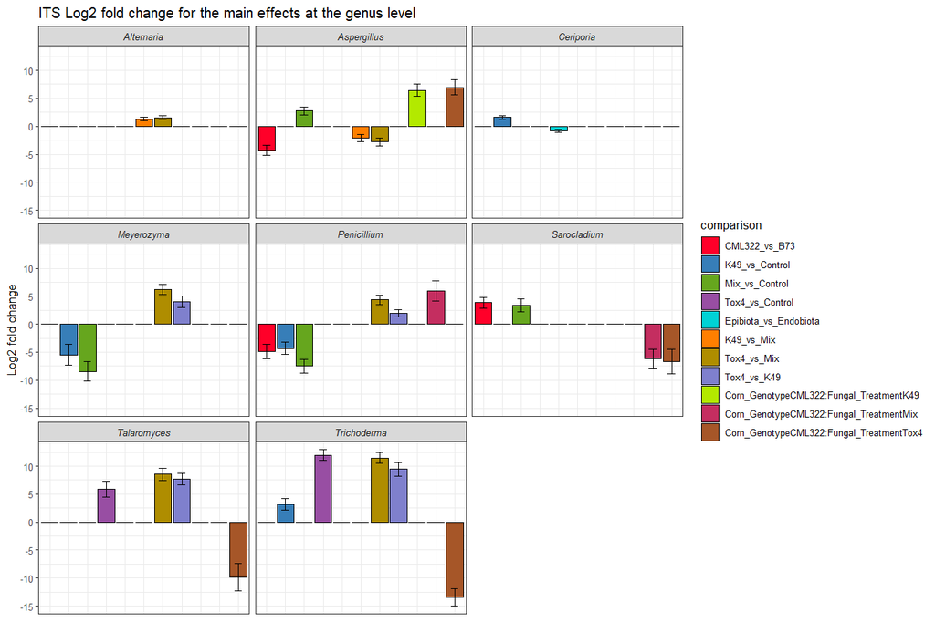

Vizualized some of the genera with a significant interaction effect.

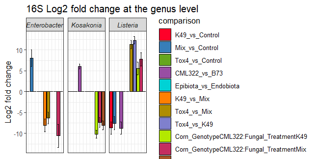

Interactions can be difficult to interpret, so I plotted the ALR (additive log ratio transformed) abundances of the above significant interactions. The interaction term can be interpreted as a difference in differences, for example Corn_GenotypeCML322:Fungal_TreatmentK49 is the effect of K49 treatment vs control in CML322 minus the effect of K49 treatment vs control in B73. The reference levels used are B73 for Corn_Genotype and Control for Fungal_Treatment.

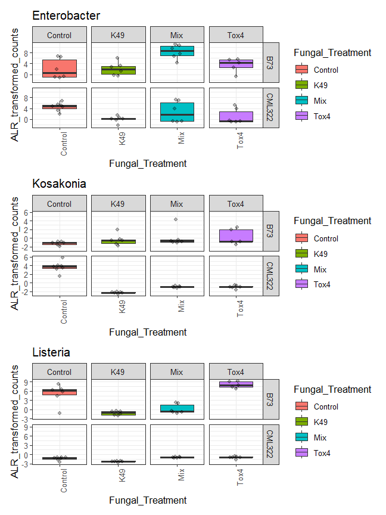

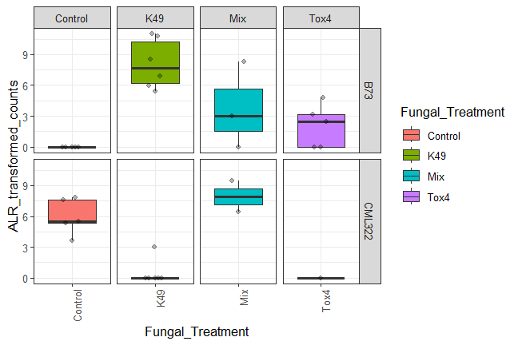

Species level bar plots showing the log2 fold change for taxa that are differentially abundant at an adjusted P value < 0.05.

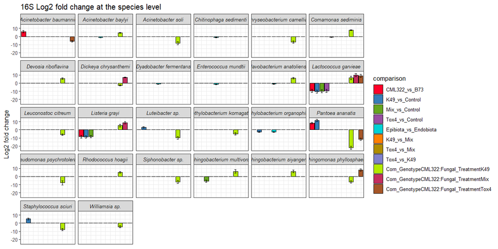

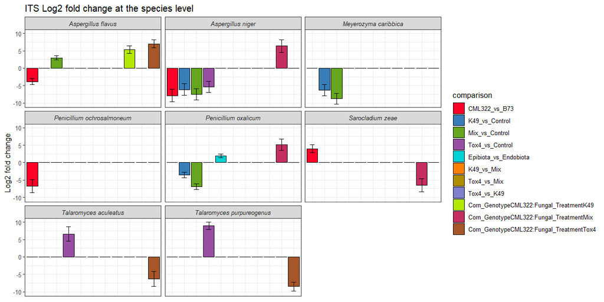

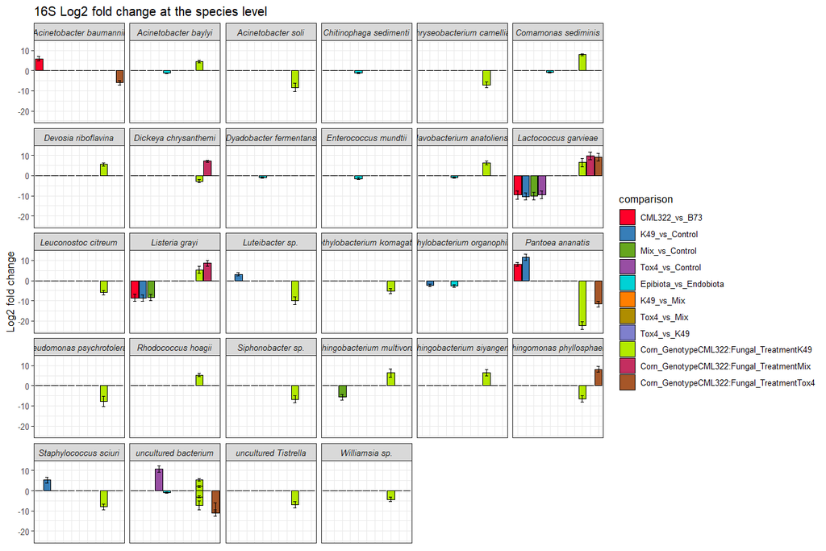

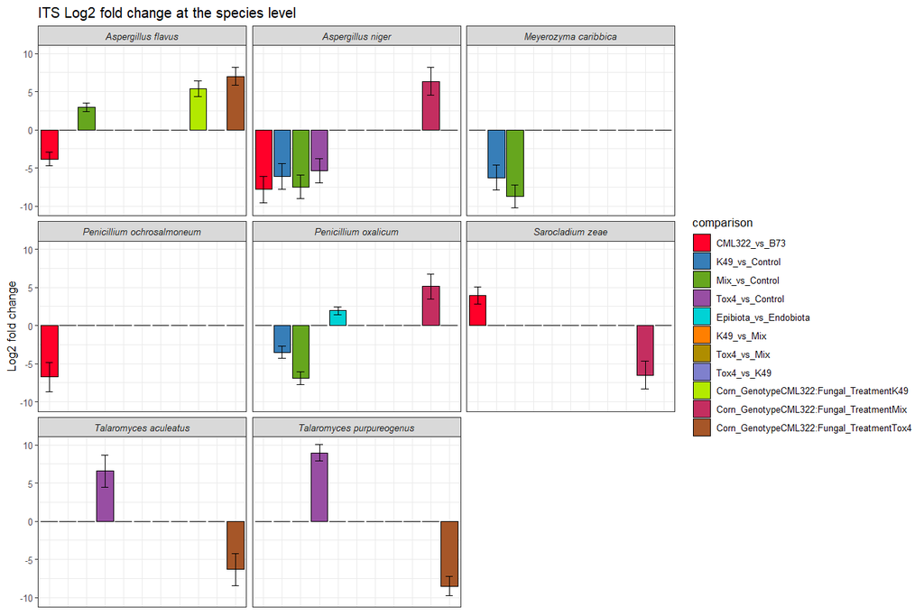

```
tidyHeatmap says: (once per session) from release 1.7.0 the scaling is set to "none" by default. Please use scale = "row", "column" or "both" to apply scaling
```

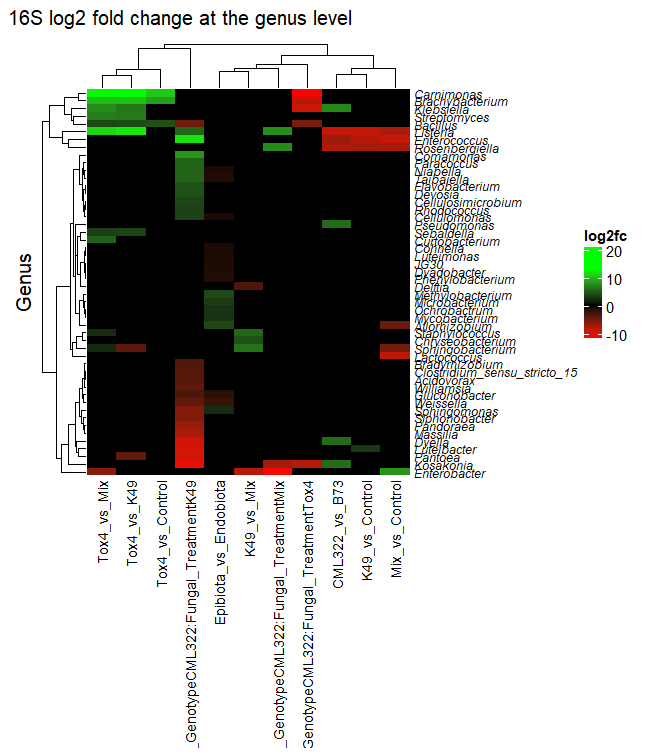

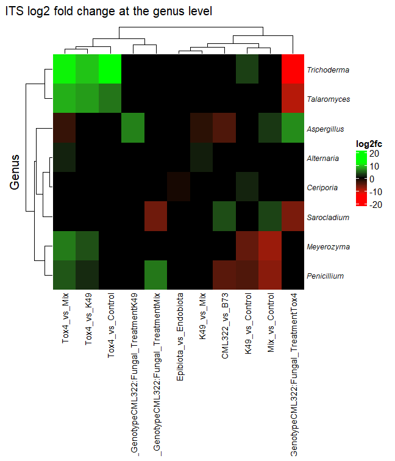

Same as above but showing species level

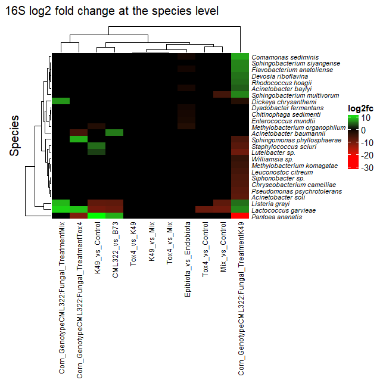

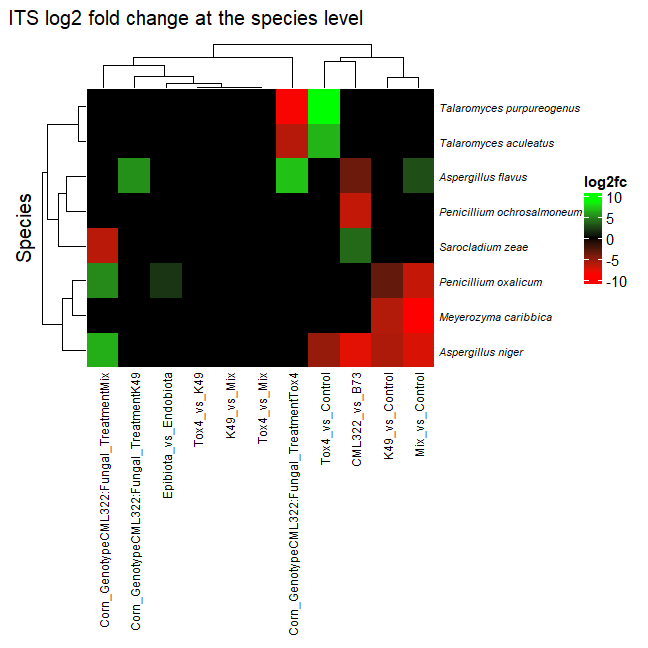